# Modeling, Inference, Prediction

The R-squared value states that 8.03% of the variation in health1 is explained by the model; however, the adjusted R-squared value, which takes into account the probability of chance associations occurring for each of the variables, states that 7.75% of the variation in health1 is explained by the model.The adjusted R-squared is likely a more accurate account of the variation explained by the model because it penalizes that value for the probability of chance. However, there are only 2 prediction variables in the model, so the difference between the R-sqaured value and the adjusted R-sqaured value is minimal.

```r
# Part 4:

# From part 3
resids<-Medicaid_lm$residuals
fitvals<-Medicaid_lm$fitted.values

# Bootstrapping
 resid_resamp<-replicate(5000,{
    new_resids<-sample(resids,replace=TRUE) #resample resids w/ replacement
    Medicaid$new_y<-fitvals+new_resids #add new resids to yhats to get new "data"
    refit<-lm(new_y~visits_c*access_c,data=Medicaid) #refit model
    coef(refit) #save coefficient estimates (b0, b1, etc)
})

# Estimated SEs
resid_resamp%>%t%>%as.data.frame%>%summarize_all(sd)
```

```
##   (Intercept)   visits_c  access_c visits_c:access_c
## 1  0.04451428 0.01338657 0.2395796        0.06869128
```

```r
# Uncorrected SEs
summary(Medicaid_lm)$coef
```

```
##                        Estimate Std. Error     t value     Pr(>|t|)
## (Intercept)        0.0009846995 0.04374773  0.02250859 9.820468e-01
## visits_c           0.1185797648 0.01338152  8.86145937 3.590791e-18
## access_c          -0.6759205791 0.23732043 -2.84813481 4.488464e-03
## visits_c:access_c -0.0548461313 0.06826226 -0.80346197 4.219002e-01
```

```r
# Corrected SEs
coeftest(Medicaid_lm, vcov = vcovHC(Medicaid_lm))
```

```
##
## t test of coefficients:
##
##                     Estimate Std. Error t value  Pr(>|t|)
## (Intercept)        0.0009847  0.0444782  0.0221 0.9823416
## visits_c           0.1185798  0.0353061  3.3586 0.0008131 ***
## access_c          -0.6759206  0.2390433 -2.8276 0.0047841 **
## visits_c:access_c -0.0548461  0.1697920 -0.3230 0.7467485
## ---
## Signif. codes:  0 '***' 0.001 '**' 0.01 '*' 0.05 '.' 0.1 ' ' 1
```

```r
# Part 5:

# Adjusting binary variable
Medicaid <- Medicaid %>% mutate(enroll_bi=ifelse(enroll=="yes",1,0))

# Logistic regression model predicting a binary variable from 2 other variables
bi_fit<-glm(enroll_bi ~ health1+access, data=Medicaid, family="binomial")

# Predicted log-odds
coeftest(bi_fit)
```

```
##
## z test of coefficients:
##
##              Estimate Std. Error z value  Pr(>|z|)
## (Intercept) -0.954810   0.159962 -5.9690 2.388e-09 ***
## health1     -0.024768   0.045261 -0.5472    0.5842
## access       2.312182   0.365465  6.3267 2.505e-10 ***
## ---
## Signif. codes:  0 '***' 0.001 '**' 0.01 '*' 0.05 '.' 0.1 ' ' 1
```

```r
# Predicted odds
exp(coeftest(bi_fit))
```

```
##
## z test of coefficients:
##
##             Estimate Std. Error  z value Pr(>|z|)
## (Intercept)  0.38489    1.17347   0.0026    1.000
## health1      0.97554    1.04630   0.5785    1.794
## access      10.09643    1.44118 559.3027    1.000
```

```r
# Predicted probability for enrollment
prob<-predict(bi_fit,type="response")
pred<-ifelse(prob>.5,1,0)

# Confusion matrix
table(prediction=pred, truth=Medicaid$enroll_bi)%>%addmargins
```

```
##           truth
## prediction   0   1 Sum
##        0   325 189 514
##        1   181 301 482
##        Sum 506 490 996
```

```r
library(knitr)
opts_chunk$set(fig.align="center", fig.height=5, message=FALSE, warning=FALSE, fig.width=8, tidy.opts=list(width.cutoff=60),tidy=TRUE)

# Classification diagnostics function
class_diag<-function(probs,truth){
  tab<-table(factor(probs>.5,levels=c("FALSE","TRUE")),truth)
  acc=sum(diag(tab))/sum(tab)
  sens=tab[2,2]/colSums(tab)[2]
  spec=tab[1,1]/colSums(tab)[1]
  ppv=tab[2,2]/rowSums(tab)[2]
  f1=2*(sens*ppv)/(sens+ppv)

  if(is.numeric(truth)==FALSE & is.logical(truth)==FALSE){
    truth<-as.numeric(truth)-1}

  # Calculating exact AUC
  ord<-order(probs, decreasing=TRUE)
  probs <- probs[ord]; truth <- truth[ord]

  TPR=cumsum(truth)/max(1,sum(truth))
  FPR=cumsum(!truth)/max(1,sum(!truth))

  dup<-c(probs[-1]>=probs[-length(probs)], FALSE)
  TPR<-c(0,TPR[!dup],1); FPR<-c(0,FPR[!dup],1)

  n <- length(TPR)
  auc<- sum( ((TPR[-1]+TPR[-n])/2) * (FPR[-1]-FPR[-n]) )

  data.frame(acc,sens,spec,ppv,f1,auc)
}

class_diag(prob, Medicaid$enroll_bi)
```

```
##         acc      sens      spec       ppv        f1       auc
## 1 0.6285141 0.6142857 0.6422925 0.6244813 0.6193416 0.6255384
```

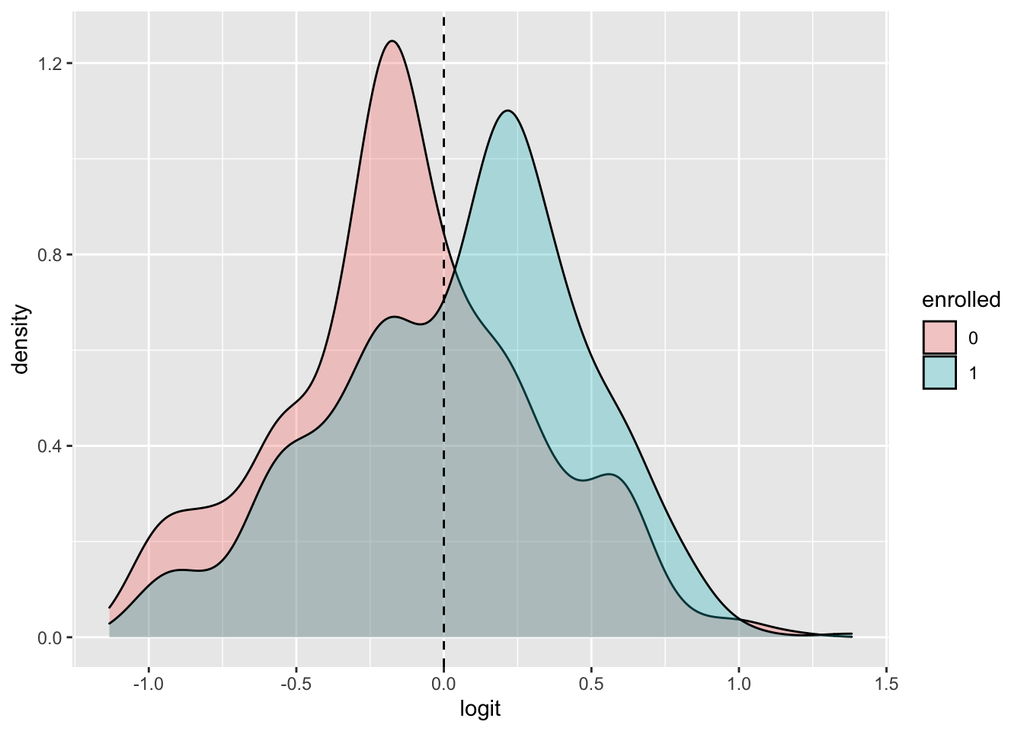

```r
# Density plot
Medicaid$logit<-predict(bi_fit, type="link")

Medicaid %>% mutate(enrolled=factor(enroll_bi,levels=c("0","1"))) %>%
ggplot(aes(logit, fill=enrolled))+geom_density(alpha=.3)+
  geom_vline(xintercept=0,lty=2)
```

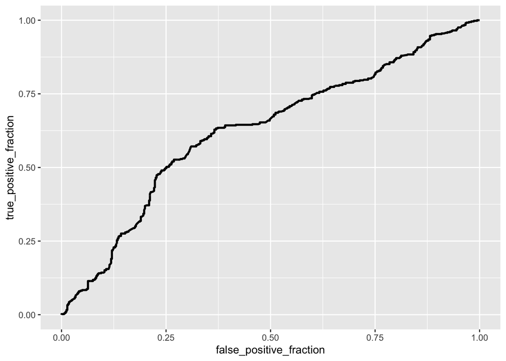

```r
# ROC curve

library(plotROC)

ggplot(Medicaid)+geom_roc(aes(d=enroll_bi,m=prob), n.cuts=0)
```

```r
MedROC<-ggplot(Medicaid)+geom_roc(aes(d=enroll_bi,m=prob), n.cuts=0)
calc_auc(MedROC)
```

```
##   PANEL group       AUC
## 1     1    -1 0.6255384
```

The accuracy of the logistic regression is 0.6285, meaning 62.85% of the particpants of the study were correctly classified as enrolled or not enrolled based on the predictive variables “health1” and “access”. The sensitivity is 0.6143, meaning 61.43% of the enrollees were correctly predicted as such when “health1” and “access” were used as predictive variables. The specificity is 0.6423, meaning 64.23% of the non-enrollees were correctly predicted as such based on the predictive variables “health1” and “access”. The precision is 0.6245, meaning 62.45% of the participants predicted to be enrolled, were actually enrolled when the predictive variables were “health1” and “access”.

The area under the curve (AUC) of the logistic regression is 0.6255, which means that the model poorly predicts the sample data when using only “health1” and “access” as predictive variables.

```r
# Part 6:

library(glmnet)

# Logistic regression model predicting a binary variable from all other variables
Medicaid <- Medicaid %>% select(-enroll, -1, -logit, -access_c, -visits_c)
all_bifit <- glm(enroll_bi ~., data=Medicaid, family="binomial")

prob2<-predict(all_bifit,type="response")
class_diag(prob2,Medicaid$enroll_bi)
```

```
##         acc      sens      spec       ppv        f1       auc
## 1 0.5983936 0.5714286 0.6245059 0.5957447 0.5833333 0.6500807
```

```r
# CV

k=10

data<-Medicaid[sample(nrow(Medicaid)),] #randomly order rows
folds<-cut(seq(1:nrow(Medicaid)),breaks=k,labels=F) #create 10 folds

diags<-NULL
for(i in 1:k){
  # Create training and test sets
  train<-data[folds!=i,]
  test<-data[folds==i,]
  truth<-test$enroll_bi

  # Train model on training set
  fit<-glm(enroll_bi~.,data=train,family="binomial")
  probs<-predict(fit,newdata = test,type="response")

  # Test model on test set (save all k results)
  diags<-rbind(diags,class_diag(probs,truth))
}

summarize_all(diags,mean)
```

```
##         acc      sens     spec       ppv        f1       auc
## 1 0.5742828 0.5452574 0.603317 0.5700921 0.5550605 0.6191777
```

```r
# Kasso

resp<-as.matrix(Medicaid$enroll_bi) # Grab response

# Scale the values
lasso_preds<-model.matrix(enroll_bi~.,data=Medicaid, response="binomial", scale)[,-1]
lasso_preds<-scale(lasso_preds)

# Always the first step of lasso
    # Picks an optimal value for lambda through 10-fold CV
lasso_cv<-cv.glmnet(lasso_preds,resp, family="binomial")

lasso_fit<-glmnet(lasso_preds,resp,family="binomial",lambda=lasso_cv$lambda.1se)

coef(lasso_fit)
```

```
## 16 x 1 sparse Matrix of class "dgCMatrix"
##                         s0
## (Intercept)    -0.03270353
## visits          .
## exposure        .
## children        .
## age             .
## income          .
## health1         .
## health2         .
## access          0.23687514
## marriedyes      .
## gendermale      .
## ethnicityother  .
## schoolcollege   .
## schoolhs        .
## schoolnone      .
## programssi      .
```

```r
# CV2

k=10

data<-Medicaid[sample(nrow(Medicaid)),] # Randomly order rows
folds<-cut(seq(1:nrow(Medicaid)),breaks=k,labels=F) # Create 10 folds

diags<-NULL
for(i in 1:k){
  # Create training and test sets
  train<-data[folds!=i,]
  test<-data[folds==i,]
  truth<-test$enroll_bi

  # Train model on training set
  fit<-glm(enroll_bi~access,data=train,family="binomial")
  probs<-predict(fit,newdata = test,type="response")

  # Test model on test set (save all k results)
  diags<-rbind(diags,class_diag(probs,truth))
}

summarize_all(diags,mean)
```

```
##         acc      sens      spec       ppv        f1       auc
## 1 0.6236061 0.6162974 0.6385502 0.6206934 0.6118298 0.6247656
```

The area under the curve (AUC) of the logistic regression is 0.6501, which means that the model poorly predicts the sample data when using all of the variables as predictors for the enrollment variable. Increasing the number of prediction variables from only “health1” and “access” to all of the variables in the model besides the response(“enroll_bi”) improved its predictions, but only slightly, and not significantly enough to improve upon its poor results.

The only variable that was retained after performing LASSO on the logistic regression model was “access” (“schoolnone” is retained sometimes after performing LASSO, likely due to it being so close to zero in a model that’s so complex; therefore, upon the advice given in the Discussion Board, I’ve chosen to be conservative and keep only the variables that don’t move much). The positive coefficient value attributed to “access” indicates that having more availability to health services, or more “access”, increases the likelihood that the person is enrolled in a demonstration program (“enroll_bi”=1). By not returning any of the other variables, the LASSO results are insinuating that they don’t have an impact the likelihood of being enrolled.